# html

## Load Data

```python
import pandas as pd
import numpy as np

breakfast_patterns = pd.read_csv('https://storage.googleapis.com/datalynn-datasets/interview-challenge/transportation/Uber_Eats_Breakfast_Service/breakfast_patterns.csv')
breakfast_menu = pd.read_csv('https://storage.googleapis.com/datalynn-datasets/interview-challenge/transportation/Uber_Eats_Breakfast_Service/breakfast_menu.csv')
delivery_metrics = pd.read_csv('https://storage.googleapis.com/datalynn-datasets/interview-challenge/transportation/Uber_Eats_Breakfast_Service/delivery_metrics.csv')

breakfast_patterns['order_time'] = pd.to_datetime(breakfast_patterns['order_time'])
```

### Question 1

*Data Manipulation & Cleaning*: Consider the `BreakfastPatterns` table. People's breakfast habits vary by the day of the week. Aggregating by weekday, identify the top 3 `preferred_breakfast` categories for each day. For instance, are weekends more indulgent with pastries compared to weekdays?

**Problem Solving Ideas and Tips**:

1. Count the number of occurrences of each `preferred_breakfast` category by day of the week.
2. Use a window function (if SQL) or a sorting mechanism (if Pandas) to get the top 3 `preferred_breakfast` categories for each day.

```python
import sqlite3

# Create a SQLite3 database in memory and transfer dataframes to SQL tables
conn = sqlite3.connect(":memory:")
breakfast_patterns.to_sql('BreakfastPatterns', conn, index=False)

sql_query = """
WITH RankedBreakfast AS (
    SELECT
        order_weekday,
        preferred_breakfast,
        COUNT(preferred_breakfast) AS frequency,
        RANK() OVER(PARTITION BY order_weekday ORDER BY COUNT(preferred_breakfast) DESC) as rank
    FROM
        BreakfastPatterns
    GROUP BY
        order_weekday, preferred_breakfast
)
SELECT
    order_weekday,
    preferred_breakfast,
    frequency
FROM
    RankedBreakfast
WHERE
    rank <= 3
ORDER BY
    order_weekday, rank;
"""

result_sql = pd.read_sql_query(sql_query, conn)
print(result_sql)
```

```
    order_weekday preferred_breakfast  frequency
0               1              Pastry         45
1               1            American         32
2               1         Continental         29
3               2            American         34
4               2             Oatmeal         30
5               2              Pastry         28
6               3            American         32
7               3              Pastry         30
8               3             Oatmeal         24
9               4              Pastry         43
10              4            American         33
11              4         Continental         29
12              5              Pastry         41
13              5            American         31
14              5             Oatmeal         27
15              6        Full English         36
16              6               Vegan         28
17              6         Continental         27
18              7        Full English         42
19              7         Continental         25
20              7               Vegan         22
21              7            American         22
```

### Question 2

*Probability and Statistics*: Using data from `DeliveryMetrics`, can you find any statistically significant trend in route_duration on Mondays (when people might be rushing to work, leading to traffic) compared to lazy Sundays?

**Problem Solving Ideas and Tips**:

1. Extract `route_duration` data for Sundays and Mondays.
2. Use statistical tests, such as the Mann-Whitney U Test, to compare the distributions of route durations for the two days. We choose this test because it does not assume a normal distribution and is suitable for comparing two independent samples.
3. Interpret the p-value from the statistical test to determine if the difference is statistically significant.

```python
# First, we merge the two datasets and filter to get the required data
merged_data = pd.merge(breakfast_patterns, delivery_metrics, left_on='user_id', right_on='order_id', how='inner')

route_durations_monday = merged_data[merged_data['order_weekday'] == 1]['route_duration']
route_durations_sunday = merged_data[merged_data['order_weekday'] == 7]['route_duration']

# Now, we'll use the Mann-Whitney U Test on the extracted data:
from scipy.stats import mannwhitneyu

statistic, p_value = mannwhitneyu(route_durations_monday, route_durations_sunday, alternative='two-sided')

print(f"Statistic: {statistic}")
print(f"P-Value: {p_value}")

if p_value < 0.05:
    print("The difference in route_duration between Monday and Sunday is statistically significant.")
else:
    print("There's no statistically significant difference in route_duration between Monday and Sunday.")
```

```
Statistic: 13673.5
P-Value: 6.334861041263357e-05
The difference in route_duration between Monday and Sunday is statistically significant.
```

### Question 3

*Machine Learning & Modeling*: Given the historical ordering data from BreakfastPatterns table which records users' preferences for different breakfast types and their ordering habits, design a clustering model that groups users with similar breakfast tastes.

**Problem Solving Ideas and Tips**:

1. Preprocessing and Encoding the Data: Firstly, preprocessing and encoding of the data is an essential step to make the data suitable for clustering.
2. Choosing Distance Metric: Given the mixture of categorical (preferred breakfast type) and numerical (order weekday and time) data, using a distance metric like the Euclidean distance might not be the best choice. Instead, a more suitable metric would be the Gower distance. However, for simplicity, if we proceed with KMeans, it uses the Euclidean distance by default. We'll assume that the standardization and one-hot encoding we performed would suffice.
3. Designing and Training the Clustering Model: KMeans is one of the most commonly used clustering methods. It’s simple and, in most cases, gives reasonably accurate results.
4. Validating the Quality of the Identified Clusters: To validate the quality of clusters without ground truth labels, the Silhouette Score is a good metric. The score ranges from -1 to 1, with 1 indicating distinct clusters and -1 indicating incorrect clusters.

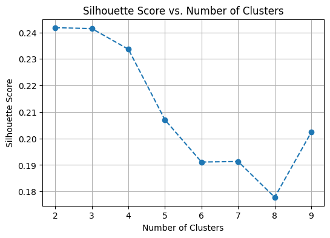

```python
from sklearn.preprocessing import StandardScaler, OneHotEncoder
from sklearn.compose import ColumnTransformer
from sklearn.pipeline import Pipeline
from sklearn.cluster import KMeans
from sklearn.metrics import silhouette_score

# Convert datetime.time to numerical format: minutes since midnight
breakfast_patterns['order_time'] = breakfast_patterns['order_time'].apply(lambda x: x.hour * 60 + x.minute)

# Separate numerical and categorical columns
num_features = ['order_weekday', 'order_time']
cat_features = ['preferred_breakfast']

# Set up the preprocessing steps for both types of features
preprocessor = ColumnTransformer(
    transformers=[
        ('num', StandardScaler(), num_features),
        ('cat', OneHotEncoder(), cat_features)
    ])

# Encoded breakfast_patterns dataframe
X_processed = preprocessor.fit_transform(breakfast_patterns)

# iterate through different numbers of clusters and compute the silhouette score for each to find the optimal number of cluster
range_n_clusters = list(range(2,10))
silhouette_scores = []
for n_clusters in range_n_clusters:
    kmeans = KMeans(n_clusters=n_clusters, n_init=10, random_state=42)
    clusters = kmeans.fit_predict(X_processed)
    silhouette_avg = silhouette_score(X_processed, clusters)
    silhouette_scores.append(silhouette_avg)

import matplotlib.pyplot as plt

# Plotting the silhouette scores
plt.figure(figsize=(6,4))
plt.plot(range_n_clusters, silhouette_scores, marker='o', linestyle='--')
plt.xlabel("Number of Clusters")
plt.ylabel("Silhouette Score")
plt.title("Silhouette Score vs. Number of Clusters")
plt.grid(True)
plt.show()
```

### Question 4

**Product Design & Analytics**: Having clustered the Uber Eats users based on their breakfast tastes using the `BreakfastPatterns` table, you've identified distinct user segments that show homogeneous preferences within each cluster. Given the clusters you've identified, how would you suggest the marketing team to leverage this segmentation to promote Uber's breakfast service? Give your recommended feature, and design an experiment to measure the effectiveness of your feature. Here are some hints for your analysis: - What star metrics and guardrail metrics you would use for the experiment? - How to validate if the order volume increase is due to these personalized promotions and not due to external factors? Discuss potential pitfalls or biases that could affect the results of your experiment and how you would account for them. - If the metric showed significant improvement in one segment but not in others, what further investigations or actions would you suggest?

#### 1. **Recommendation:**

Given the distinct user segments that have been identified based on breakfast tastes, a targeted marketing approach can be employed. We suggest creating **personalized breakfast promotion campaigns** for each cluster. For instance, if a cluster heavily leans towards 'Vegan' breakfast, they can receive promotions from vegan-friendly restaurants during breakfast hours or special offers on vegan breakfast dishes.

#### 2. **Feature:**

**"Personalized Breakfast Recommendations"** - When users open the Uber Eats app during breakfast hours, they see a highlighted section showcasing breakfast dishes based on their cluster preference.

#### 3. **Experiment Design:**

**3.1. Star Metrics:**

- **Order Volume for Breakfast**: The number of breakfast orders placed. This metric will directly capture the impact of the personalized recommendations.
- **Click-through Rate (CTR) on Recommended Dishes**: The number of clicks on the recommended dishes divided by the number of impressions.

**3.2. Guardrail Metrics:**

- **Overall User Engagement**: To ensure the feature doesn't negatively impact user interaction with the app.
- **Order Volume for Other Meals**: To ensure the feature doesn't cannibalize lunch or dinner orders.

**3.3. Experiment Setup:**

- **A/B Testing**: Randomly divide the users into two groups.
  - **Control Group**: They see the general promotions as they currently exist.
  - **Test Group**: They see the "Personalized Breakfast Recommendations" feature.

**3.4. Validation:** To validate if the order volume increase is genuinely due to these personalized promotions:

- **Duration**: Run the experiment for a few weeks to account for weekly variations.
- **Seasonality Control**: Ensure the experiment runs during a seasonally consistent period, avoiding major holidays or events.

**3.5. Potential Pitfalls & Biases:**

- **Selection Bias**: Ensure random assignment of users to control and test groups to avoid any selection biases.
- **External Factors**: There might be external promotions or campaigns running simultaneously that could affect order volumes. Be aware of any other marketing campaigns during the experiment duration.
- **Novelty Effect**: Users might interact with the new feature just because it's new. The initial spike might not represent long-term behavior. It's essential to run the experiment long enough to account for this.

**3.6. Evaluation**: If the metric showed significant improvement in the test group compared to the control group and there's no negative impact on guardrail metrics, consider the feature successful and think about rolling it out to a broader audience.

By following this experiment design, Uber Eats can make an informed decision on whether personalized breakfast recommendations can drive user engagement and increase breakfast order volume.

```python
from sklearn.cluster import KMeans

def minutes_to_hour_string(minutes):
    return f"{minutes // 60}:{minutes % 60:02d}"

# 1. Fit KMeans with n_clusters=4
kmeans = KMeans(n_clusters=3, n_init=10, random_state=42)
clusters = kmeans.fit_predict(X_processed)

# Attach the cluster assignments to the original data
breakfast_patterns['cluster'] = clusters

# Initialize a list to store results
cluster_summary = []

# Loop through each cluster to determine the most frequent preferred_breakfast, order_weekday and most common order hour and minute
for cluster in range(3):
    cluster_data = breakfast_patterns[breakfast_patterns['cluster'] == cluster]

    # Find the most frequent preferred breakfast and order_weekday for this cluster
    most_common_breakfast = cluster_data['preferred_breakfast'].value_counts().idxmax()
    most_common_weekday = cluster_data['order_weekday'].mode().iloc[0]  # mode returns a Series, take the first item

    # Find the most common order time (in minutes) for this cluster and convert it back to hour:minute format
    most_common_order_time_minutes = cluster_data['order_time'].mode().iloc[0]
    most_common_order_time_string = minutes_to_hour_string(most_common_order_time_minutes)

    cluster_summary.append({
        'cluster': cluster,
        'most_common_breakfast': most_common_breakfast,
        'most_common_weekday': most_common_weekday,
        'most_common_order_time': most_common_order_time_string
    })

# Convert the results into a DataFrame
cluster_summary_df = pd.DataFrame(cluster_summary)
cluster_summary_df
```

|  | cluster | most_common_breakfast | most_common_weekday | most_common_order_time |
| --- | --- | --- | --- | --- |
| 0 | 0 | Full English | 7 | 7:40 |
| 1 | 1 | Oatmeal | 1 | 10:55 |
| 2 | 2 | Pastry | 4 | 7:40 |